# R code for Figure 2 - MA plots of differentially expressed genes and heatmap of top SI genes

Xiao Xu (xxu@rockefeller.edu)

June 2018

Xu X, Stoyanova EI, Lemiesz A, Xing J, Mash DC, Heintz N (2018). Species and Cell-Type Properties of Classically Defined Human and Rodent Neurons and Glia.

Specifically, this workflow will generate the MA plots and heatmap of top SI gene expression for Figure 2.

Load libraries and functions:

```r
# source custom functions
source("functions.R")
# libraries for gene expression analysis
library(DESeq2)
# libraries for heatmaps and colors
library(RColorBrewer)
library(gplots)
# data manipulation
library(plyr)
# work in the tidyverse
library(tidyverse)
library(ggrepel)
```

## Import counts

Read in table of counts generated from featureCounts:

```r
# read in table of counts
counts <- read_tsv("../data/rat_all_wg_counts.txt")
```

Create metadata for samples:

```r
cell_types <- c("Unsorted", "Granule", "Purkinje", "Basket", "Astrocyte", "Oligo", "OPC")
meta <- tibble(
  Sample = colnames(counts)[-1],
  Cell_type = rep(
    cell_types,
    each = 2
    )
  )
```

Read in table of marker genes for each cell type:

```r
markers <- read_tsv("../data/cell_type_markers.txt")
```

## MA plots

| Name | All | Up | Down |
| --- | --- | --- | --- |
| Granule | 1476 | 694 | 782 |

| Name | All | Up | Down |
| --- | --- | --- | --- |
| Purkinje | 2976 | 1482 | 1494 |

| Name | All | Up | Down |
| --- | --- | --- | --- |
| Basket | 1955 | 867 | 1088 |

| Name | All | Up | Down |
| --- | --- | --- | --- |
| Astrocyte | 2461 | 1329 | 1132 |

| Name | All | Up | Down |
| --- | --- | --- | --- |
| Oligo | 3389 | 1627 | 1762 |

| Name | All | Up | Down |
| --- | --- | --- | --- |
| OPC | 1638 | 992 | 646 |

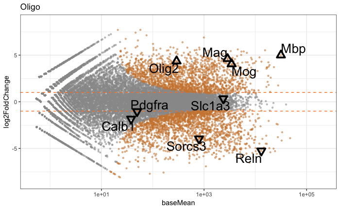

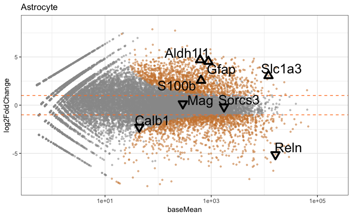

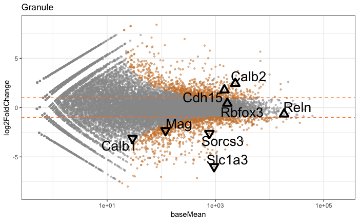

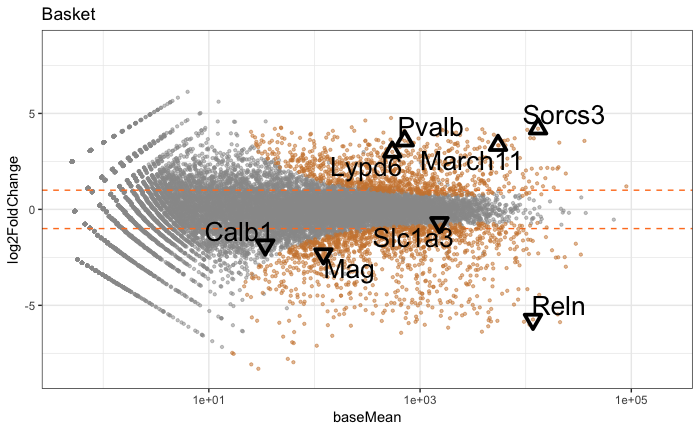

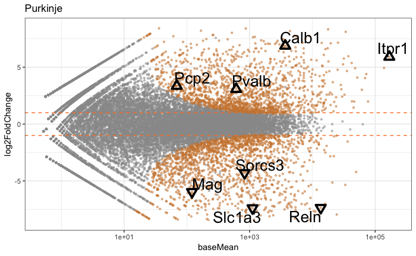

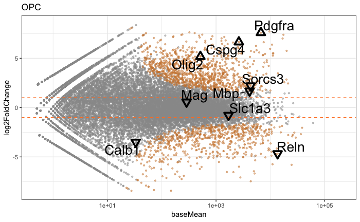

```r
# for each cell type, perform differential expression compared
# to unsorted, print number of significant genes
# and generate MA plot
getDEStatsAndPlot <- function(counts, meta, ct, p, bm) {
  de <- getDECustom(counts, meta, "Unsorted", ct)
  printDE(de, p, bm, ct)
  ma <- plotMACustom(de, alpha = p,
                     markers = markers %>%
                       filter(Cell_type == ct) %>%
                       select(-Cell_type)) +
    ggtitle(ct)
  ggsave(paste("figure_2_main_ma_", tolower(ct), ".pdf", sep = ""),
         ma, device = "pdf", path = "../figures/",
         width = 11, height = 8.5, units = "in")
  ma
}
# p-value cutoff for stats and plotting
# basemean cutoff for stats
p <- 10e-5
bm <- 50

# apply above function to all cell types except for unsorted
lapply(
  cell_types[-1],
  function(x) getDEStatsAndPlot(counts, meta, x, p, bm)
)
```

## Human

### Import counts

Read in table of counts generated from featureCounts:

```r
# read in table of counts
counts <- read_tsv("../data/human_xk_pk_wg_counts.txt")
```

Create metadata for samples:

```r
meta <- tibble(
  Sample = colnames(counts)[-1],
  Cell_type = rep(
    c("Granule", "Basket", "Astrocyte", "Oligo", "OPC"),
    each = 2
    ),
  Individual = rep(c("XK", "PK"), 5)
  )
```

### Normalize counts

Use rlog transformation in deseq2 to normalize counts:

```r
# create dds object
dds <- DESeqDataSetFromMatrix(counts %>% column_to_rownames("Gene"),
                              meta %>% column_to_rownames("Sample"),
                              design =~ Cell_type)
```

```
Setting row names on a tibble is deprecated.Setting row names on a tibble is deprecated.some variables in design formula are characters, converting to factors
```

```r
dds <- DESeq(dds)
# get normalized counts using rlog transformation
rld <- rlogTransformation(dds, blind = TRUE)
rld_table <- assay(rld)
# save normalized counts
write_rds(rld, "../data_clean/figure_2_main_human_norm_rld.RDS")
```

### Plot heatmap

Perform hierarchical clustering with the 250 most variable genes:

```r
top_var_genes <- head(order(rowVars(rld_table), decreasing = TRUE), 250)
mat <- rld_table[top_var_genes, ]
hc <- hclust( dist( t(mat) ) )
```

Calculate pearson correlation coeffcients across all samples:

```r
pairwise <- cor(rld_table)
colnames(pairwise) <- rownames(pairwise) <- colData(dds)$condition
```

Specify colors for heatmap:

```r
# specify color palette and breaks
cor_col <- colorRampPalette( brewer.pal(9, "YlOrRd") )(100)
cor_breaks <- seq(0.9, 1, length.out = 101)
# sidebar for heatmap.2
sidebar <- c(rep("green", 2), rep("orange", 2), rep("blue", 2),
             rep("cyan", 2), rep("skyblue", 2))
```

Plot heatmap:

```r
# save to pdf
pdf("../figures/figure_2_main_heatmap_human_cor.pdf", width = 11, height = 8.5)
hm <- heatmap.2(
  pairwise,
  Rowv = as.dendrogram(hc),
  symm = TRUE, revC = TRUE,
  scale = "none", trace = "none",
  ColSideColors = sidebar,
  notecol = "black", notecex = 0.25,
  col = cor_col, breaks = cor_breaks,
  key.title = NA, key.ylab = NA,
  cexRow = 1, cexCol = 1, margins = c(6, 6),
  labCol = FALSE, labRow = FALSE,
  keysize = 1, key.par = list(mar = c(4, 2, 1, 1))
)
dev.off()
```

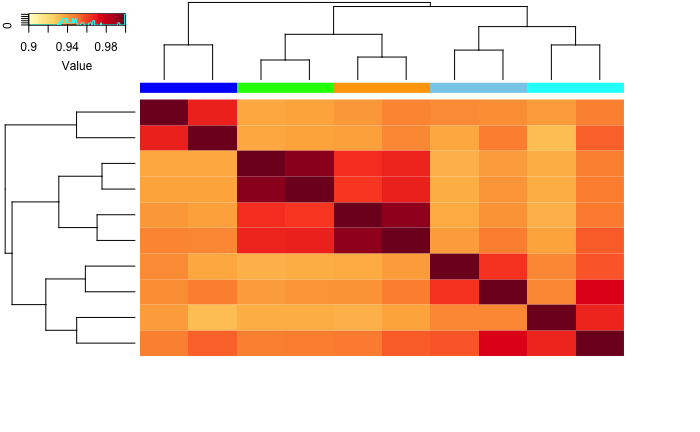

```r
# and display in this file
eval(hm$call)
```

# Plot SI heatmap

Normalize counts by length using FPKM (RPKM) calculation:

```r
# read in gene lengths
lengths <- read_tsv("../data/ref/hg38_refseq_wg_longest.txt",
                    col_names = c("Gene", "Length"))
# calculate rpkms
rpkms <- getNormCounts(counts, lengths, type = "RPKM")
```

```
Setting row names on a tibble is deprecated.
```

Calculate SI on server using parallel processing. With parallel off, takes around 1.5 hours to run for 1,000 iterations:

```r
set.seed(1)
si_table <- siWithReps(rpkms %>% as.data.frame(),
                       meta$Cell_type,
                       bottom = 0, reps = TRUE, iterations = 1000,
                       parallel = TRUE, cores = 32)
write_tsv(si_table %>%
            as.data.frame() %>%
            rownames_to_column("Gene"),
          "../output/si_human.txt")
```

Read in specificity index data, identify the top 20 genes for each cell type, and get rpkms for each gene across all conditions:

```r
# read in specificity index table
si_table <- read_tsv("../output/si_human.txt") %>%
  column_to_rownames("Gene")
# get top 20 si genes for each cell type
si_top20 <- as.vector( apply(si_table, 2, sortedIndex, table=si_table, top=20) )
# get rpkms for top si genes
rpkms_si <- expFromGeneList(rpkms, si_top20)
# convert rpkms to z scores for heatmap plotting
mat <- as.matrix( apply(rpkms_si, 1, getZScores) )
```

Specify heatmap palette and sidebar colors

```r
# palette for z-scores
cor_col <- rev( colorRampPalette( brewer.pal(9, 'RdBu') )(100) )
cor_breaks <- seq(-2.5, 2.5, length.out = 101)
# sidebar for heatmap.2
cell_type_cols <- c(
  Granule = "#33A02C",
  Basket = "#FF6600",
  Astrocyte = "#0033FF",
  Oligo = "#00CCCC",
  OPC = "#00FFFF"
)
sidebar_row <- rep(cell_type_cols, each = 2)
sidebar_col <- rep(cell_type_cols, each = 20)
```

Final heatmap:

```r
pdf("../figures/figure_2_main_heatmap_human_si.pdf", width = 11, height = 8.5)
hm <- heatmap.2(
  mat,
  dendrogram = "none", Rowv = FALSE, Colv = FALSE, # no dendrogram, no reordering
  col = cor_col, breaks = cor_breaks,  # colors for values
  RowSideColors = sidebar_row, ColSideColors = sidebar_col,  # sidebar
  scale = "none", trace = "none",
  key.title = NA, key.ylab = NA,
  cexRow = 1, cexCol = 1, margins = c(2, 2),
  labCol = FALSE, labRow = FALSE,
  keysize = 1, key.par = list(mar = c(4, 2, 1, 1))
)
dev.off()
```

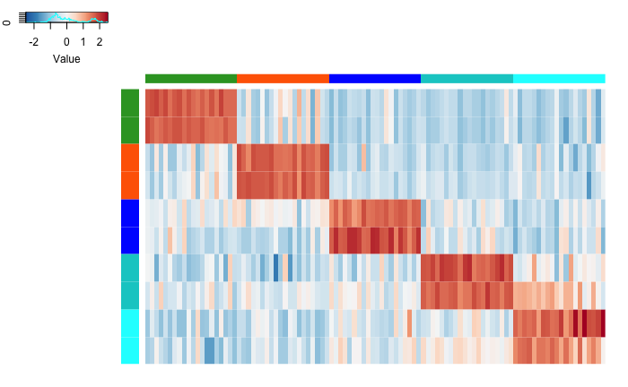

```r
# and display in this file
eval(hm$call)
```